# Obj2.1: Complex Linear Model

Ahmed Awadallah

2022-06-05

## Setup Libs

```r
library(magrittr)
library(ggplot2)
library(dplyr)
library(tidyverse)
library(GGally)
library(car)
library(glmnet)
library(reshape2)

#Change working directory to this source file directory
setwd(dirname(rstudioapi::getSourceEditorContext()$path))

#Load my custom functions
source("personal_funcs.r")
```

## NA Row Removal Impact Analysis

Most of these Countriess lose all their data except for 2

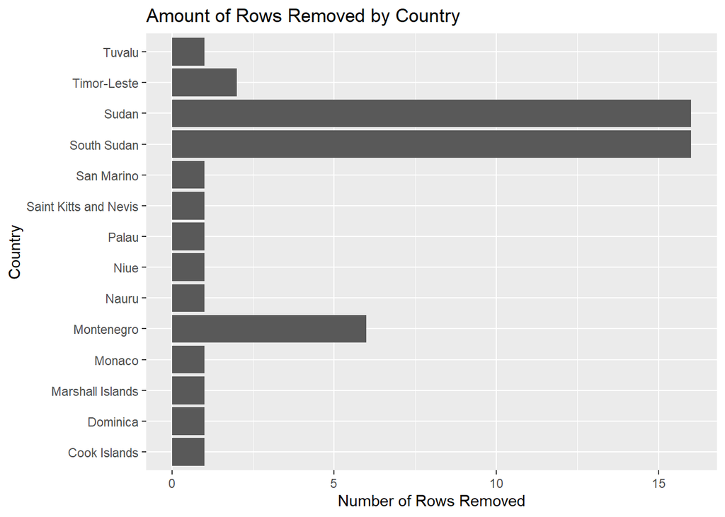

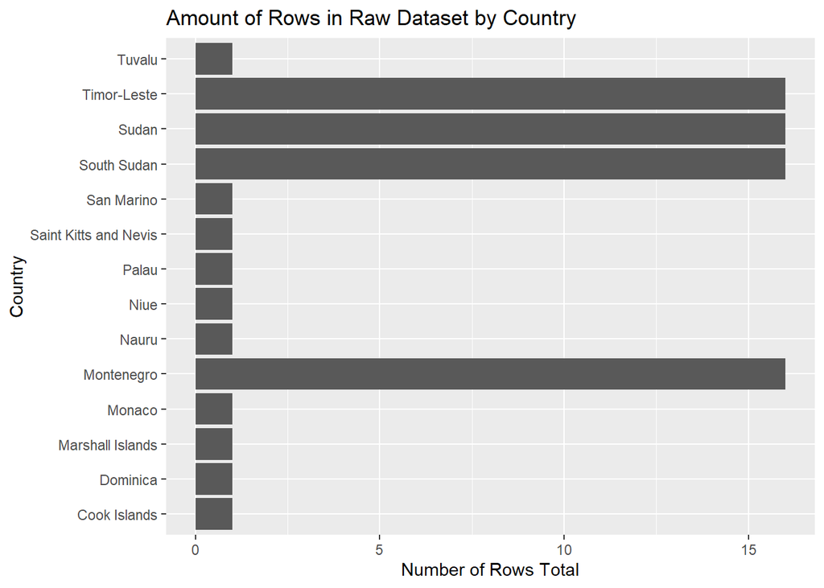

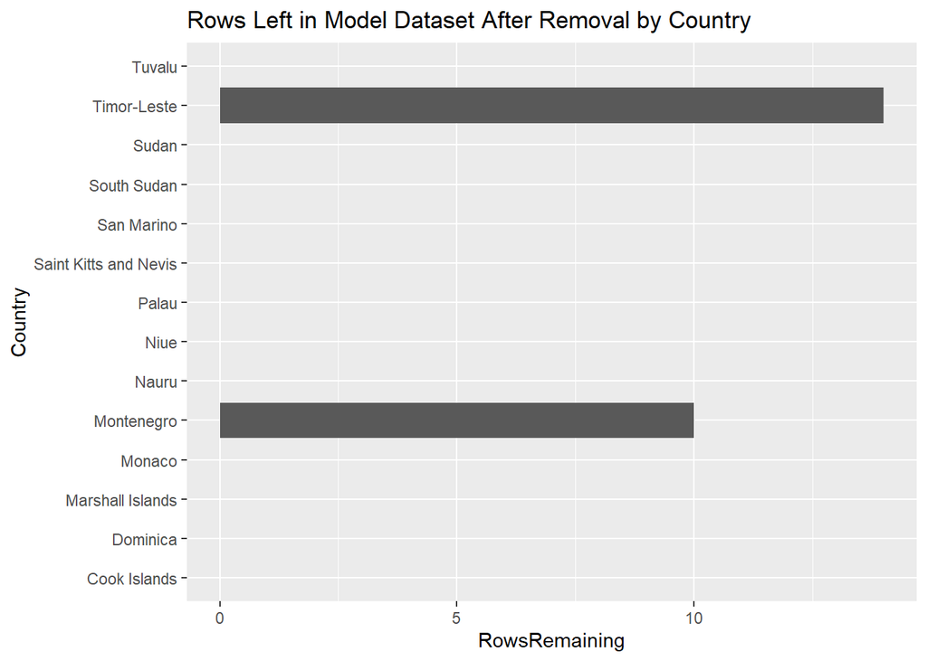

## Remove NAs, Adjust Variable Types, and Standardize Data

```r
#Remove High NA Features and Clean Data
#High NA vars have More than 5% missing
#Country is not included as the name of a country should not be a useful factor in prediction, the countriess
#Life expectancy is determined by their policies not a string of characters
variablesWithHighNa = c("Total.expenditure", "Schooling", "Population", "Income.composition.of.resources",
                        "Hepatitis.B", "GDP", "Alcohol", "Country")
LifeExpecClean = LifeExpecRaw %>% select(-variablesWithHighNa)

#RemoveNAs
LifeExpecClean$Status = as.factor(LifeExpecClean$Status)
LifeExpecClean = LifeExpecClean %>% filter(!is.na(Life.expectancy))
LifeExpecClean = LifeExpecClean %>% filter(!is.na(BMI))
LifeExpecClean = LifeExpecClean %>% filter(!is.na(Adult.Mortality))
LifeExpecClean = LifeExpecClean %>% filter(!is.na(Diphtheria))
LifeExpecClean = LifeExpecClean %>% filter(!is.na(Polio))
LifeExpecClean = LifeExpecClean %>% filter(!is.na(thinness..1.19.years))
LifeExpecClean = LifeExpecClean %>% filter(!is.na(thinness.5.9.years))

#How much of the original dataset did we remove: around 1%
PercentDataRemoved = (dim(LifeExpecRaw)[1] - dim(LifeExpecClean)[1])/dim(LifeExpecRaw)[1]*100
cat("Percent of data removed: ", PercentDataRemoved)
```

```
## Percent of data removed:  1.701838
```

```r
cat("Exact Number of Rows Removed: ", dim(LifeExpecRaw)[1] - dim(LifeExpecClean)[1])
```

```
## Exact Number of Rows Removed:  50
```

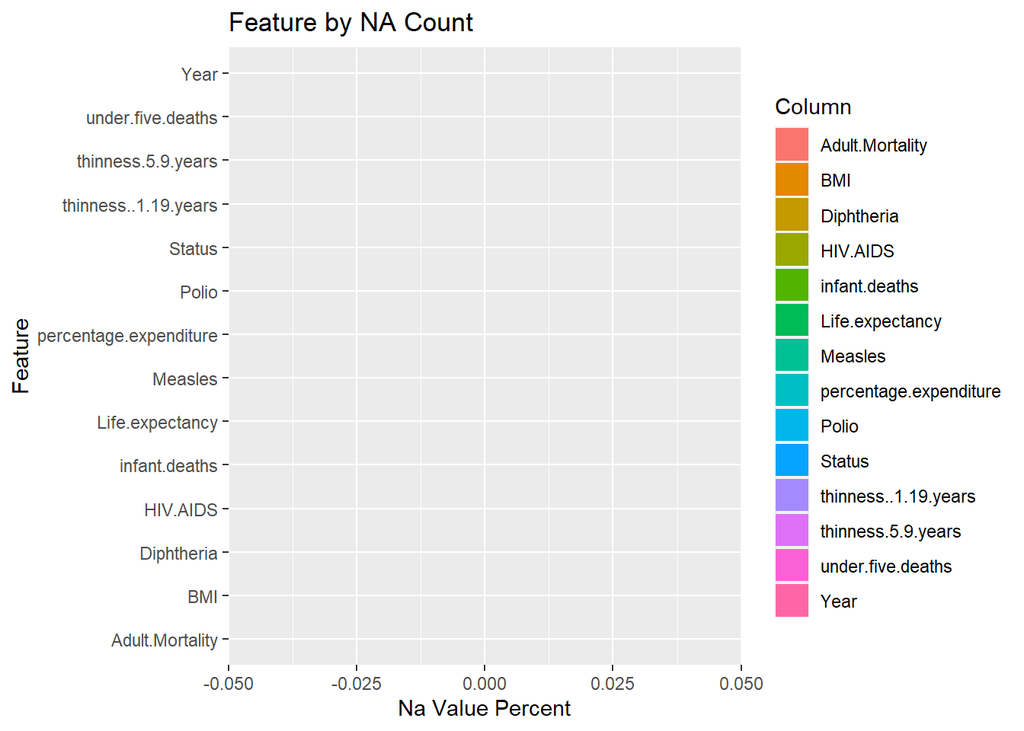

```r
#Adjusting variable types
LifeExpecClean$Year = as.numeric(LifeExpecClean$Year)
LifeExpecClean$Adult.Mortality = as.numeric(LifeExpecClean$Adult.Mortality)
LifeExpecClean$infant.deaths = as.numeric(LifeExpecClean$infant.deaths)
LifeExpecClean$Measles = as.numeric(LifeExpecClean$Measles)
LifeExpecClean$under.five.deaths = as.numeric(LifeExpecClean$under.five.deaths)
LifeExpecClean$Polio = as.numeric(LifeExpecClean$Polio)
LifeExpecClean$Diphtheria = as.numeric(LifeExpecClean$Diphtheria)

#Verify no NAs
LifeExpecClean %>%
  summarise(across(everything(), ~ sum(is.na(.x)))/2938*100) %>%
  gather(Column, NA_Count) %>%
  ggplot(aes(x=NA_Count, y=Column, fill = Column)) + geom_col() +
  ylab("Feature") + xlab("Na Value Percent") +
  ggtitle("Feature by NA Count")
```

```r
#Transform a feature prior to standardization as it will report NA values if we dont do it now
LifeExpecClean$LogOneOverHIV.AIDS = log(1/LifeExpecClean$HIV.AIDS)
LifeExpecCleanS = LifeExpecClean
#Standardize
vars = c("Year", "Life.expectancy", "Adult.Mortality", "infant.deaths",
         "percentage.expenditure", "Measles", "BMI", "under.five.deaths",
         "Polio", "Diphtheria", "HIV.AIDS", "thinness..1.19.year", "thinness.5.9.years",
         "LogOneOverHIV.AIDS")
LifeExpecClean = get_standardized_df(LifeExpecClean, vars)
```

## Train Val Test Setup

```r
#Train Validation Test Setup
set.seed(1)
testSplitPercent = 0.9
trainTestList = get_train_test_list(LifeExpecClean, testSplitPercent)

trainValIndex = 1
testIndex = 2
TrainVal = trainTestList[[trainValIndex]]
Test = trainTestList[[testIndex]]

testRows = dim(Test)[1]
trainValRows = dim(TrainVal)[1]

valSplitPercent = 1 - (testRows/trainValRows)
trainValList = get_train_test_list(TrainVal, valSplitPercent)

trainIndex = 1
valIndex = 2
Train = trainValList[[trainIndex]]
Val = trainValList[[valIndex]]
```

## Model 1: No adjustment

```r
##Model 1: Everything that doesnt have excessive NA values is in the model

#Var Selection
variablesToRemove = c("LogOneOverHIV.AIDS") #Transformed feature is used later
Train1 = Train %>% select(-variablesToRemove)
Val1 = Val %>% select(-variablesToRemove)

#LM Model
linearModel1 = lm(Life.expectancy ~., data = Train1)

#Model Stats
summary(linearModel1)
```

```
##
## Call:
## lm(formula = Life.expectancy ~ ., data = Train1)
##
## Residuals:
##      Min       1Q   Median       3Q      Max
## -2.58886 -0.28084  0.01947  0.28703  1.62085
##
## Coefficients:
##                         Estimate Std. Error t value Pr(>|t|)
## (Intercept)             0.471001   0.041645  11.310  < 2e-16 ***
## Year                    0.054260   0.010215   5.312 1.19e-07 ***
## StatusDeveloping       -0.415321   0.031524 -13.175  < 2e-16 ***
## Adult.Mortality        -0.307157   0.013052 -23.533  < 2e-16 ***
## infant.deaths           1.455762   0.124027  11.737  < 2e-16 ***
## percentage.expenditure  0.103103   0.011093   9.294  < 2e-16 ***
## Measles                -0.021691   0.010932  -1.984   0.0474 *
## BMI                     0.169328   0.012732  13.299  < 2e-16 ***
## under.five.deaths      -1.463747   0.123933 -11.811  < 2e-16 ***
## Polio                   0.104796   0.013902   7.538 6.81e-14 ***
## Diphtheria              0.122315   0.014039   8.712  < 2e-16 ***
## HIV.AIDS               -0.237804   0.011778 -20.191  < 2e-16 ***
## thinness..1.19.years   -0.026734   0.006717  -3.980 7.10e-05 ***
## thinness.5.9.years      0.027948   0.030082   0.929   0.3530
## ---
## Signif. codes:  0 '***' 0.001 '**' 0.01 '*' 0.05 '.' 0.1 ' ' 1
##
## Residual standard error: 0.4806 on 2296 degrees of freedom
## Multiple R-squared:  0.7672, Adjusted R-squared:  0.7659
## F-statistic: 582.1 on 13 and 2296 DF,  p-value: < 2.2e-16
```

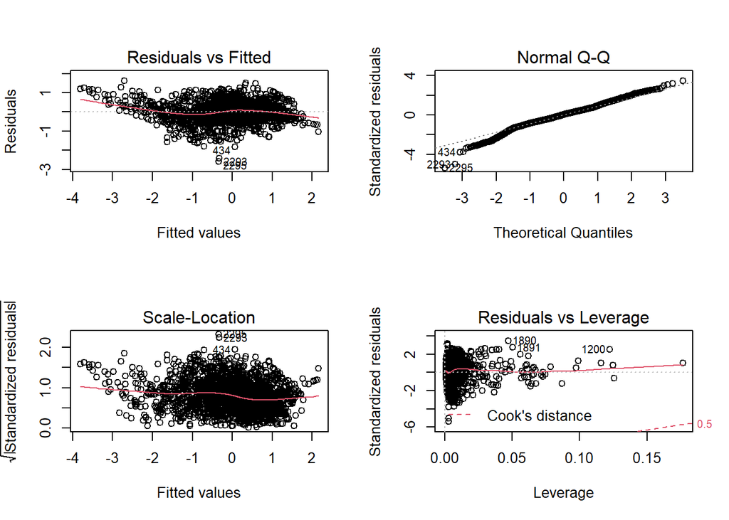

```r
#Assumption Check
par(mfrow=c(2,2))
plot(linearModel1)
```

```r
par(mfrow=c(1,1))
vif(linearModel1)^2
```

```
##                   Year                 Status        Adult.Mortality
##               1.092125               2.145276               2.856213
##          infant.deaths percentage.expenditure                Measles
##           22921.057329               1.677429               1.852343
##                    BMI      under.five.deaths                  Polio
##               2.613556           23394.141632               3.521953
##             Diphtheria               HIV.AIDS   thinness..1.19.years
##               3.642964               2.081458              80.970957
##     thinness.5.9.years
##              85.781084
```

```r
#Model Performance Stats:
Predictions = predict(linearModel1, Val1)
ase1 = get_ase(Predictions, Val1$Life.expectancy)
cat("ASE: ", ase1)
```

```
## ASE:  0.2639953
```

```r
cat("AIC: ", AIC(linearModel1))
```

```
## AIC:  3186.316
```

## LASSO: Feature Selection

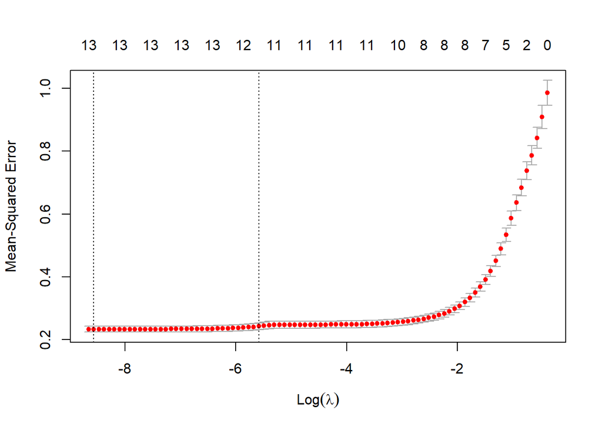

```r
Train1Features = Train1
Train1Features = model.matrix(Life.expectancy~.,Train1Features)[,-1]
Train1Target = Train1$Life.expectancy

Val1Features = Val1
Val1Features = model.matrix(Life.expectancy~.,Val1Features)[,-1]
Val1Target = Val1$Life.expectancy

grid=10^seq(10,-2, length =100)
lasso.mod=glmnet(Train1Features,Train1Target,alpha=1, lambda =grid)
cv.out=cv.glmnet(Train1Features,Train1Target,alpha=1) #alpha=1 performs LASSO
plot(cv.out)
```

```r
bestlambda<-cv.out$lambda.min
lasso.pred=predict (lasso.mod ,s=bestlambda ,newx=Val1Features)

testMSE_LASSO<-mean((Val1Target-lasso.pred)^2)
cat("MSE: ", testMSE_LASSO)
```

```
## MSE:  0.27683
```

```r
coef(lasso.mod,s=bestlambda)
```

```
## 14 x 1 sparse Matrix of class "dgCMatrix"
##                                  s1
## (Intercept)             0.408938336
## Year                    0.048059295
## StatusDeveloping       -0.392141840
## Adult.Mortality        -0.315010899
## infant.deaths           .
## percentage.expenditure  0.096126564
## Measles                -0.025659725
## BMI                     0.173032897
## under.five.deaths      -0.009412443
## Polio                   0.110990101
## Diphtheria              0.142195939
## HIV.AIDS               -0.242911607
## thinness..1.19.years   -0.017928444
## thinness.5.9.years      .
```

infant.deaths and thinness.5.9.years have no significant coefficient so remove these two features and move forward with the model process.

## Model 2: Insignificant Lasso Terms Removed

```r
##Model 2: Remove features lasso found useless
#Use coef to remove terms
#Remove:
#infant.deaths: 0
#thinness.5.9.years: 0

#Post Lasso Var Selection
variablesToRemove = c("infant.deaths", "thinness.5.9.years", "LogOneOverHIV.AIDS")
Train2 = Train %>% select(-variablesToRemove)
Val2 = Val %>% select(-variablesToRemove)

#LM Model
linearModel2 = lm(Life.expectancy ~., data = Train2)

#Model Stats
summary(linearModel2)
```

```
##
## Call:
## lm(formula = Life.expectancy ~ ., data = Train2)
##
## Residuals:
##      Min       1Q   Median       3Q      Max
## -2.64004 -0.28337  0.02539  0.28635  1.50597
##
## Coefficients:
##                         Estimate Std. Error t value Pr(>|t|)
## (Intercept)             0.417065   0.029674  14.055  < 2e-16 ***
## Year                    0.055661   0.010521   5.291 1.33e-07 ***
## StatusDeveloping       -0.401829   0.032427 -12.392  < 2e-16 ***
## Adult.Mortality        -0.316616   0.013415 -23.602  < 2e-16 ***
## percentage.expenditure  0.101395   0.011424   8.876  < 2e-16 ***
## Measles                -0.030762   0.011229  -2.739   0.0062 **
## BMI                     0.174285   0.012991  13.416  < 2e-16 ***
## under.five.deaths      -0.013735   0.013323  -1.031   0.3027
## Polio                   0.113910   0.014291   7.971 2.46e-15 ***
## Diphtheria              0.144472   0.014331  10.081  < 2e-16 ***
## HIV.AIDS               -0.248457   0.012092 -20.548  < 2e-16 ***
## thinness..1.19.years   -0.017962   0.003124  -5.749 1.02e-08 ***
## ---
## Signif. codes:  0 '***' 0.001 '**' 0.01 '*' 0.05 '.' 0.1 ' ' 1
##
## Residual standard error: 0.495 on 2298 degrees of freedom
## Multiple R-squared:  0.7528, Adjusted R-squared:  0.7516
## F-statistic: 636.2 on 11 and 2298 DF,  p-value: < 2.2e-16
```

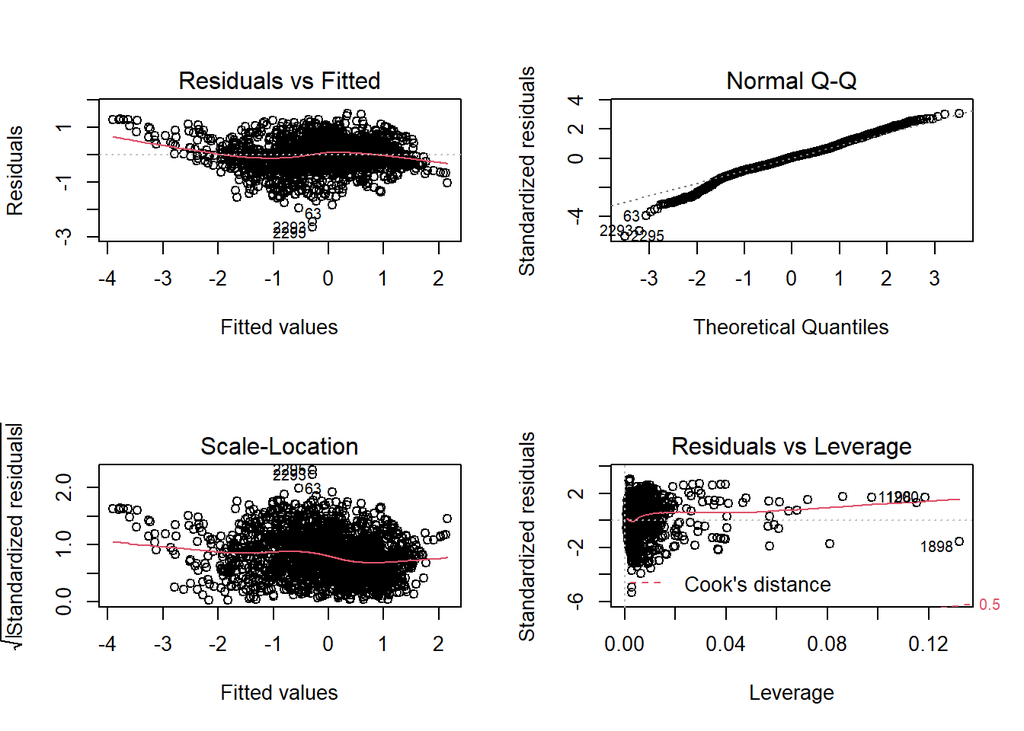

```r
#Assumption Check
par(mfrow=c(2,2))
plot(linearModel2)
```

```r
par(mfrow=c(1,1))
vif(linearModel2)^2
```

```
##                   Year                 Status        Adult.Mortality
##               1.091836               2.133856               2.830991
## percentage.expenditure                Measles                    BMI
##               1.675971               1.831927               2.515883
##      under.five.deaths                  Polio             Diphtheria
##               2.775675               3.494321               3.514071
##               HIV.AIDS   thinness..1.19.years
##               2.054408               3.366960
```

## Model 3: Use Complex Features to Improve the Model

```r
##Model 3: Now create a complex model to help explain the data more
#Now deal with polynomial behavior
#Variables polynoial behavior profiles
  #Year: Linear, x
  #Status: Categorical (Not adjusted)
  #percentage.expenditure: 1 vertex even: X^2
  #Adult.Mortality: Nonlinear 1 vertex even: x^2
  #BMI: Nonlinear 3 vertices even: x^4
  #Measles: Nonlinear mostly 1 vertex even: x^2
  #under.five.deaths: Nonlinear 3 vertices even: x^4
  #Polio: Nonlinear 2 Vertices odd: X^3
  #Diphtheria: Nonlinear 2 vertices odd: x^3
  #HIV.AIDS: Nonlinear: 1/x then log to prevent normalization issues
  #thinness..1.19.years: Nonlinear 3 vertices even: X^4
variablesToRemove = c("infant.deaths", "thinness.5.9.years", "HIV.AIDS")
Train3 = Train %>% select(-variablesToRemove)
Val3 = Val %>% select(-variablesToRemove)

linearModel3 = lm(Life.expectancy ~ Year + Status +
                    Adult.Mortality + Adult.Mortality^2 +
                    percentage.expenditure + percentage.expenditure^2 +
                    BMI + BMI^2 + BMI^3 + BMI^4 +
                    Measles + Measles^2 +
                    under.five.deaths + under.five.deaths^2 + under.five.deaths^3 + under.five.deaths^4 +
                    Polio + Polio^2 + Polio^3 +
                    Diphtheria + Diphtheria^2 + Diphtheria^3 +
                    LogOneOverHIV.AIDS + #This transformation was done prior to standardization so just call the feature
                    thinness..1.19.years + thinness..1.19.years^2 + thinness..1.19.years^3 + thinness..1.19.years^4,
                  data = Train3)

#Model Stats
summary(linearModel3) #Now under.five.deaths no longer significant. Remove
```

```
##
## Call:
## lm(formula = Life.expectancy ~ Year + Status + Adult.Mortality +
##     Adult.Mortality^2 + percentage.expenditure + percentage.expenditure^2 +
##     BMI + BMI^2 + BMI^3 + BMI^4 + Measles + Measles^2 + under.five.deaths +
##     under.five.deaths^2 + under.five.deaths^3 + under.five.deaths^4 +
##     Polio + Polio^2 + Polio^3 + Diphtheria + Diphtheria^2 + Diphtheria^3 +
##     LogOneOverHIV.AIDS + thinness..1.19.years + thinness..1.19.years^2 +
##     thinness..1.19.years^3 + thinness..1.19.years^4, data = Train3)
##
## Residuals:
##      Min       1Q   Median       3Q      Max
## -2.14086 -0.25577  0.00526  0.25572  1.44456
##
## Coefficients:
##                         Estimate Std. Error t value Pr(>|t|)
## (Intercept)             0.362760   0.025481  14.237  < 2e-16 ***
## Year                    0.075894   0.008961   8.469  < 2e-16 ***
## StatusDeveloping       -0.329917   0.027830 -11.855  < 2e-16 ***
## Adult.Mortality        -0.218127   0.011806 -18.477  < 2e-16 ***
## percentage.expenditure  0.097371   0.009783   9.953  < 2e-16 ***
## BMI                     0.079815   0.011434   6.981 3.83e-12 ***
## Measles                -0.021450   0.009629  -2.228    0.026 *
## under.five.deaths      -0.011271   0.011408  -0.988    0.323
## Polio                   0.074172   0.012294   6.033 1.87e-09 ***
## Diphtheria              0.093160   0.012346   7.546 6.44e-14 ***
## LogOneOverHIV.AIDS      0.470230   0.012541  37.495  < 2e-16 ***
## thinness..1.19.years   -0.019781   0.002673  -7.399 1.91e-13 ***
## ---
## Signif. codes:  0 '***' 0.001 '**' 0.01 '*' 0.05 '.' 0.1 ' ' 1
##
## Residual standard error: 0.4242 on 2298 degrees of freedom
## Multiple R-squared:  0.8185, Adjusted R-squared:  0.8176
## F-statistic: 941.8 on 11 and 2298 DF,  p-value: < 2.2e-16
```

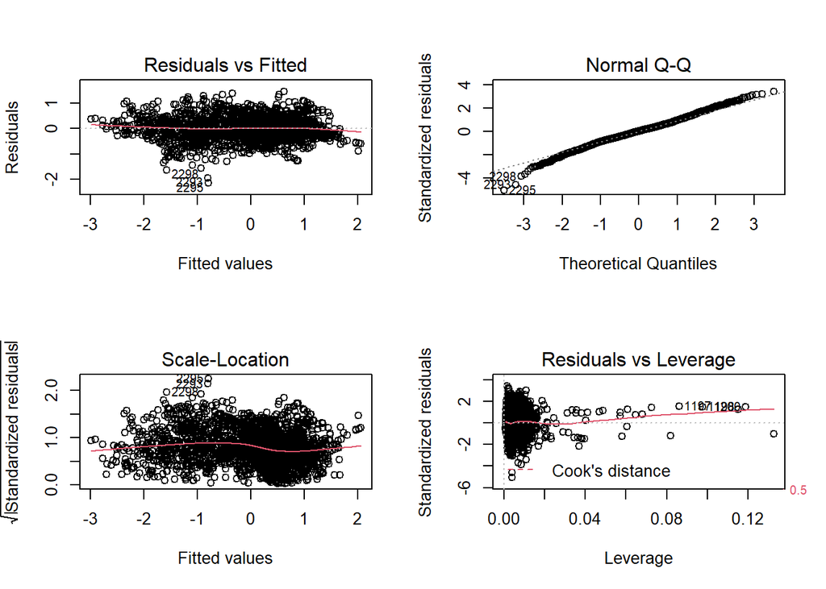

```r
#Assumption Check
par(mfrow=c(2,2))
plot(linearModel3)
```

```r
par(mfrow=c(1,1))
vif(linearModel3)^2
```

```
##                   Year                 Status        Adult.Mortality
##               1.065495               2.146325               3.148357
## percentage.expenditure                    BMI                Measles
##               1.671303               2.799304               1.836022
##      under.five.deaths                  Polio             Diphtheria
##               2.766647               3.547627               3.588124
##     LogOneOverHIV.AIDS   thinness..1.19.years
##               4.018743               3.346355
```

## Model 4: Remove the Year Feature

Year probably violates independence assumption of our model so it’s being removed here and a new model is trained without it.

```r
##Model 4: Remove a serial feature
#Years is technically time dependent but our analysis assumes no time dependence. Try a model without years

variablesToRemove = c("infant.deaths", "thinness.5.9.years", "HIV.AIDS", "Year")
Train4 = Train %>% select(-variablesToRemove)
Val4 = Val %>% select(-variablesToRemove)

linearModel4 = lm(Life.expectancy ~ Status +
                    Adult.Mortality + Adult.Mortality^2 +
                    percentage.expenditure + percentage.expenditure^2 +
                    BMI + BMI^2 + BMI^3 + BMI^4 +
                    Measles + Measles^2 +
                    under.five.deaths + under.five.deaths^2 + under.five.deaths^3 + under.five.deaths^4 +
                    Polio + Polio^2 + Polio^3 +
                    Diphtheria + Diphtheria^2 + Diphtheria^3 +
                    LogOneOverHIV.AIDS + #This transformation was done prior to standardization so just call the feature
                    thinness..1.19.years + thinness..1.19.years^2 + thinness..1.19.years^3 + thinness..1.19.years^4,
                  data = Train4)

#Model Stats
summary(linearModel4) #under.five.deaths not significant. Remove
```

```
##
## Call:
## lm(formula = Life.expectancy ~ Status + Adult.Mortality + Adult.Mortality^2 +
##     percentage.expenditure + percentage.expenditure^2 + BMI +
##     BMI^2 + BMI^3 + BMI^4 + Measles + Measles^2 + under.five.deaths +
##     under.five.deaths^2 + under.five.deaths^3 + under.five.deaths^4 +
##     Polio + Polio^2 + Polio^3 + Diphtheria + Diphtheria^2 + Diphtheria^3 +
##     LogOneOverHIV.AIDS + thinness..1.19.years + thinness..1.19.years^2 +
##     thinness..1.19.years^3 + thinness..1.19.years^4, data = Train4)
##
## Residuals:
##      Min       1Q   Median       3Q      Max
## -2.20949 -0.26066  0.00356  0.25400  1.41981
##
## Coefficients:
##                         Estimate Std. Error t value Pr(>|t|)
## (Intercept)             0.350941   0.025831  13.586  < 2e-16 ***
## StatusDeveloping       -0.315349   0.028201 -11.182  < 2e-16 ***
## Adult.Mortality        -0.220513   0.011982 -18.403  < 2e-16 ***
## percentage.expenditure  0.099303   0.009930  10.000  < 2e-16 ***
## BMI                     0.086638   0.011579   7.482 1.04e-13 ***
## Measles                -0.026346   0.009758  -2.700  0.00699 **
## under.five.deaths      -0.008637   0.011578  -0.746  0.45573
## Polio                   0.073868   0.012481   5.918 3.74e-09 ***
## Diphtheria              0.100491   0.012504   8.037 1.46e-15 ***
## LogOneOverHIV.AIDS      0.471400   0.012732  37.025  < 2e-16 ***
## thinness..1.19.years   -0.019770   0.002714  -7.284 4.43e-13 ***
## ---
## Signif. codes:  0 '***' 0.001 '**' 0.01 '*' 0.05 '.' 0.1 ' ' 1
##
## Residual standard error: 0.4307 on 2299 degrees of freedom
## Multiple R-squared:  0.8128, Adjusted R-squared:  0.812
## F-statistic: 998.1 on 10 and 2299 DF,  p-value: < 2.2e-16
```

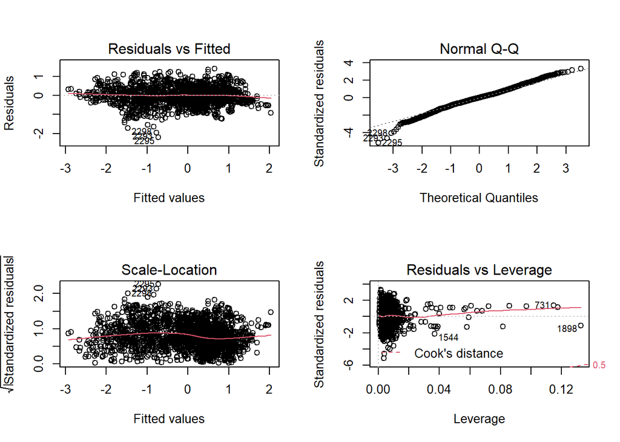

```r
#Assumption Check
par(mfrow=c(2,2))
plot(linearModel4)
```

```r
par(mfrow=c(1,1))
vif(linearModel4)^2
```

```
##                 Status        Adult.Mortality percentage.expenditure
##               2.129958               3.144772               1.669485
##                    BMI                Measles      under.five.deaths
##               2.771582               1.822809               2.762539
##                  Polio             Diphtheria     LogOneOverHIV.AIDS
##               3.547566               3.552929               4.017768
##   thinness..1.19.years
##               3.346354
```

## Model 5: Remove under.five.deaths

under.five.deaths is no longer a significant term in the model so remove it

```r
#Model 5. under.five.deaths removed as it is not a significant term

variablesToRemove = c("infant.deaths", "thinness.5.9.years", "HIV.AIDS", "Year", "under.five.deaths")
Train5 = Train %>% select(-variablesToRemove)
Val5 = Val %>% select(-variablesToRemove)

linearModel5 = lm(Life.expectancy ~ Status +
                    Adult.Mortality + Adult.Mortality^2 +
                    percentage.expenditure + percentage.expenditure^2 +
                    BMI + BMI^2 + BMI^3 + BMI^4 +
                    Measles + Measles^2 +
                    Polio + Polio^2 + Polio^3 +
                    Diphtheria + Diphtheria^2 + Diphtheria^3 +
                    LogOneOverHIV.AIDS +
                    thinness..1.19.years + thinness..1.19.years^2 + thinness..1.19.years^3 + thinness..1.19.years^4,
                  data = Train5)

#Model Stats
summary(linearModel5)
```

```
##
## Call:
## lm(formula = Life.expectancy ~ Status + Adult.Mortality + Adult.Mortality^2 +
##     percentage.expenditure + percentage.expenditure^2 + BMI +
##     BMI^2 + BMI^3 + BMI^4 + Measles + Measles^2 + Polio + Polio^2 +
##     Polio^3 + Diphtheria + Diphtheria^2 + Diphtheria^3 + LogOneOverHIV.AIDS +
##     thinness..1.19.years + thinness..1.19.years^2 + thinness..1.19.years^3 +
##     thinness..1.19.years^4, data = Train5)
##
## Residuals:
##      Min       1Q   Median       3Q      Max
## -2.20666 -0.26066  0.00457  0.25246  1.41752
##
## Coefficients:
##                         Estimate Std. Error t value Pr(>|t|)
## (Intercept)             0.353704   0.025562  13.837  < 2e-16 ***
## StatusDeveloping       -0.313984   0.028139 -11.159  < 2e-16 ***
## Adult.Mortality        -0.220405   0.011980 -18.397  < 2e-16 ***
## percentage.expenditure  0.099243   0.009929   9.996  < 2e-16 ***
## BMI                     0.086277   0.011568   7.458 1.24e-13 ***
## Measles                -0.029634   0.008705  -3.404 0.000675 ***
## Polio                   0.074256   0.012469   5.955 3.00e-09 ***
## Diphtheria              0.101004   0.012483   8.091 9.48e-16 ***
## LogOneOverHIV.AIDS      0.471165   0.012727  37.022  < 2e-16 ***
## thinness..1.19.years   -0.020577   0.002489  -8.268 2.28e-16 ***
## ---
## Signif. codes:  0 '***' 0.001 '**' 0.01 '*' 0.05 '.' 0.1 ' ' 1
##
## Residual standard error: 0.4307 on 2300 degrees of freedom
## Multiple R-squared:  0.8127, Adjusted R-squared:  0.812
## F-statistic:  1109 on 9 and 2300 DF,  p-value: < 2.2e-16
```

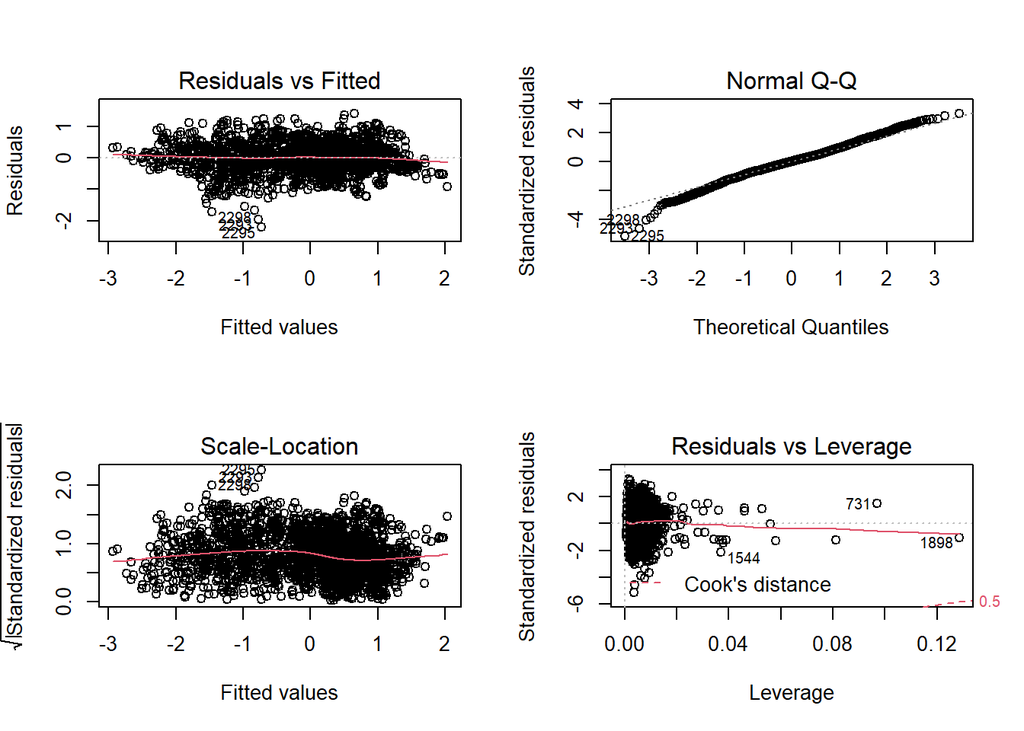

```r
#Assumption Check
par(mfrow=c(2,2))
plot(linearModel5)
```

```r
par(mfrow=c(1,1))
vif(linearModel5)^2
```

```
##                 Status        Adult.Mortality percentage.expenditure
##               2.112056               3.143856               1.669267
##                    BMI                Measles                  Polio
##               2.761937               1.155046               3.535233
##             Diphtheria     LogOneOverHIV.AIDS   thinness..1.19.years
##               3.531473               4.012860               2.367231
```

## Model Average Loop

Get AIC and Validation set ASE from multiple iterations to get a good average for all the models. These average stats are then compared to select a model.

```r
#Compare all models using multiple train validation splits to average out randomness
#Var Setup
modelIterations = 500 #The larger this term the more time this takes
aseModel1 = 0
aseModel2 = 0
aseModel3 = 0
aseModel4 = 0
aseModel5 = 0
aicModel1 = 0
aicModel2 = 0
aicModel3 = 0
aicModel4 = 0
aicModel5 = 0

#Loop creates a train validation split then evaluates the ase and AIC. Do this
#modelIterations amount of times and average result.
for(i in 1:modelIterations){
  #Train Validation Setup
  trainValList = get_train_test_list(TrainVal, valSplitPercent)
  trainIndex = 1
  valIndex = 2

  Train = trainValList[[trainIndex]]
  Val = trainValList[[valIndex]]

  #Train Val dataframes for each model
  variablesToRemove = c("LogOneOverHIV.AIDS")
  Train1 = Train %>% select(-variablesToRemove)
  Val1 = Val %>% select(-variablesToRemove)

  variablesToRemove = c("infant.deaths", "thinness.5.9.years", "LogOneOverHIV.AIDS")
  Train2 = Train %>% select(-variablesToRemove)
  Val2 = Val %>% select(-variablesToRemove)

  variablesToRemove = c("infant.deaths", "thinness.5.9.years", "HIV.AIDS")
  Train3 = Train %>% select(-variablesToRemove)
  Val3 = Val %>% select(-variablesToRemove)

  variablesToRemove = c("infant.deaths", "thinness.5.9.years", "HIV.AIDS", "Year")
  Train4 = Train %>% select(-variablesToRemove)
  Val4 = Val %>% select(-variablesToRemove)

  variablesToRemove = c("infant.deaths", "thinness.5.9.years", "HIV.AIDS", "Year", "under.five.deaths")
  Train5 = Train %>% select(-variablesToRemove)
  Val5 = Val %>% select(-variablesToRemove)



  #Models
  linearModel1 = lm(Life.expectancy ~., data = Train1)
  linearModel2 = lm(Life.expectancy ~., data = Train2)

  linearModel3 = lm(Life.expectancy ~ Year + Status +
                      Adult.Mortality + Adult.Mortality^2 +
                      percentage.expenditure + percentage.expenditure^2 +
                      BMI + BMI^2 + BMI^3 + BMI^4 +
                      Measles + Measles^2 +
                      under.five.deaths + under.five.deaths^2 + under.five.deaths^3 + under.five.deaths^4 +
                      Polio + Polio^2 + Polio^3 +
                      Diphtheria + Diphtheria^2 + Diphtheria^3 +
                      LogOneOverHIV.AIDS +
                      thinness..1.19.years + thinness..1.19.years^2 + thinness..1.19.years^3 + thinness..1.19.years^4,
                    data = Train3)
  linearModel4 = lm(Life.expectancy ~ Status +
                      Adult.Mortality + Adult.Mortality^2 +
                      percentage.expenditure + percentage.expenditure^2 +
                      BMI + BMI^2 + BMI^3 + BMI^4 +
                      Measles + Measles^2 +
                      under.five.deaths + under.five.deaths^2 + under.five.deaths^3 + under.five.deaths^4 +
                      Polio + Polio^2 + Polio^3 +
                      Diphtheria + Diphtheria^2 + Diphtheria^3 +
                      LogOneOverHIV.AIDS +
                      thinness..1.19.years + thinness..1.19.years^2 + thinness..1.19.years^3 + thinness..1.19.years^4,
                    data = Train4)

  linearModel5 = lm(Life.expectancy ~ Status +
                      Adult.Mortality + Adult.Mortality^2 +
                      percentage.expenditure + percentage.expenditure^2 +
                      BMI + BMI^2 + BMI^3 + BMI^4 +
                      Measles + Measles^2 +
                      Polio + Polio^2 + Polio^3 +
                      Diphtheria + Diphtheria^2 + Diphtheria^3 +
                      LogOneOverHIV.AIDS +
                      thinness..1.19.years + thinness..1.19.years^2 + thinness..1.19.years^3 + thinness..1.19.years^4,
                    data = Train5)

  #Get ase for each model
  #M1
  Predictions = predict(linearModel1, Val1)
  ase = get_ase(Predictions, Val1$Life.expectancy)
  aseModel1 = aseModel1 + ase

  #M2
  Predictions = predict(linearModel2, Val2)
  ase = get_ase(Predictions, Val2$Life.expectancy)
  aseModel2 = aseModel2 + ase

  #M3
  Predictions = predict(linearModel3, Val3)
  ase = get_ase(Predictions, Val3$Life.expectancy)
  aseModel3 = aseModel3 + ase

  #M4
  Predictions = predict(linearModel4, Val4)
  ase = get_ase(Predictions, Val4$Life.expectancy)
  aseModel4 = aseModel4 + ase

  #M5
  Predictions = predict(linearModel5, Val5)
  ase = get_ase(Predictions, Val5$Life.expectancy)
  aseModel5 = aseModel5 + ase

  #Get AIC
  aicModel1 = aicModel1 + AIC(linearModel1)
  aicModel2 = aicModel2 + AIC(linearModel2)
  aicModel3 = aicModel3 + AIC(linearModel3)
  aicModel4 = aicModel4 + AIC(linearModel4)
  aicModel5 = aicModel5 + AIC(linearModel5)
}

#Average Everything
aseModel1 = aseModel1/modelIterations
aseModel2 = aseModel2/modelIterations
aseModel3 = aseModel3/modelIterations
aseModel4 = aseModel4/modelIterations
aseModel5 = aseModel5/modelIterations
aicModel1 = aicModel1/modelIterations
aicModel2 = aicModel2/modelIterations
aicModel3 = aicModel3/modelIterations
aicModel4 = aicModel4/modelIterations
aicModel5 = aicModel5/modelIterations

#Test dataframes for each model
variablesToRemove = c("LogOneOverHIV.AIDS")
Test1 = Test %>% select(-variablesToRemove)

variablesToRemove = c("infant.deaths", "thinness.5.9.years", "LogOneOverHIV.AIDS")
Test2 = Test %>% select(-variablesToRemove)

variablesToRemove = c("infant.deaths", "thinness.5.9.years", "HIV.AIDS")
Test3 = Test %>% select(-variablesToRemove)

variablesToRemove = c("infant.deaths", "thinness.5.9.years", "HIV.AIDS", "Year")
Test4 = Test %>% select(-variablesToRemove)

variablesToRemove = c("infant.deaths", "thinness.5.9.years", "HIV.AIDS", "Year", "under.five.deaths")
Test5 = Test %>% select(-variablesToRemove)

#Get Test ASE
Predictions = predict(linearModel1, Test1)
ase1 = get_ase(Predictions, Test1$Life.expectancy)

Predictions = predict(linearModel2, Test2)
ase2 = get_ase(Predictions, Test2$Life.expectancy)

Predictions = predict(linearModel3, Test3)
ase3 = get_ase(Predictions, Test3$Life.expectancy)

Predictions = predict(linearModel4, Test4)
ase4 = get_ase(Predictions, Test4$Life.expectancy)

Predictions = predict(linearModel5, Test5)
ase5 = get_ase(Predictions, Test5$Life.expectancy)

#Unstandardized version of final model ASE
Predictions = predict(linearModel5, Test5)
UnstandardizedPredictions = Predictions*sd(LifeExpecCleanS$Life.expectancy) + mean(LifeExpecCleanS$Life.expectancy)
UnstandardizedTargets = Test5$Life.expectancy*sd(LifeExpecCleanS$Life.expectancy) + mean(LifeExpecCleanS$Life.expectancy)
ase5Unstandardized = get_ase(UnstandardizedPredictions, UnstandardizedTargets)

#TrainVal ASE AIC Scores Table Setup
modelNum = c(1:5)
trainAIC = c(aicModel1, aicModel2, aicModel3, aicModel4, aicModel5)
valASE = c(aseModel1, aseModel2, aseModel3, aseModel4, aseModel5)
testASE = c(ase1, ase2, ase3, ase4, ase5)
testASEUnstandard = c(NA, NA, NA, NA, ase5Unstandardized)
modelCompareDf = data.frame(modelNum = modelNum, trainAIC = trainAIC, valASE = valASE, testASE = testASE, testASEUnstandard = testASEUnstandard)
```

## Model Comparison Table

```
##   modelNum trainAIC    valASE   testASE testASEUnstandard
## 1        1 3221.668 0.2364409 0.2385296                NA
## 2        2 3353.374 0.2504088 0.2617465                NA
## 3        3 2643.523 0.1835583 0.1926085                NA
## 4        4 2704.794 0.1882450 0.1949383                NA
## 5        5 2703.706 0.1881469 0.1950666          17.58787
```

## Final Model Stats

Technically best model is model 3 but this had serial behavior present which may break our models independence assumption. We will take a score hit for doing this but our variables now better align with assumptions of our model giving us more confidence in our results as a benefit. The next best model is model 5 as its AIC score and its ASE is less than the rest. Use LM5 for final report

#### Summary

```
##
## Call:
## lm(formula = Life.expectancy ~ Status + Adult.Mortality + Adult.Mortality^2 +
##     percentage.expenditure + percentage.expenditure^2 + BMI +
##     BMI^2 + BMI^3 + BMI^4 + Measles + Measles^2 + Polio + Polio^2 +
##     Polio^3 + Diphtheria + Diphtheria^2 + Diphtheria^3 + LogOneOverHIV.AIDS +
##     thinness..1.19.years + thinness..1.19.years^2 + thinness..1.19.years^3 +
##     thinness..1.19.years^4, data = Train5)
##
## Residuals:
##      Min       1Q   Median       3Q      Max
## -2.18844 -0.25978  0.00103  0.26098  1.42310
##
## Coefficients:
##                         Estimate Std. Error t value Pr(>|t|)
## (Intercept)             0.348026   0.026005  13.383  < 2e-16 ***
## StatusDeveloping       -0.302905   0.028608 -10.588  < 2e-16 ***
## Adult.Mortality        -0.210170   0.012064 -17.422  < 2e-16 ***
## percentage.expenditure  0.103297   0.009862  10.474  < 2e-16 ***
## BMI                     0.097291   0.011477   8.477  < 2e-16 ***
## Measles                -0.023327   0.009241  -2.524   0.0117 *
## Polio                   0.080274   0.012368   6.490 1.05e-10 ***
## Diphtheria              0.100471   0.012216   8.225 3.24e-16 ***
## LogOneOverHIV.AIDS      0.473720   0.012869  36.810  < 2e-16 ***
## thinness..1.19.years   -0.020001   0.002521  -7.933 3.31e-15 ***
## ---
## Signif. codes:  0 '***' 0.001 '**' 0.01 '*' 0.05 '.' 0.1 ' ' 1
##
## Residual standard error: 0.4341 on 2300 degrees of freedom
## Multiple R-squared:  0.8118, Adjusted R-squared:  0.811
## F-statistic:  1102 on 9 and 2300 DF,  p-value: < 2.2e-16
```

#### True v Predicted Scatter

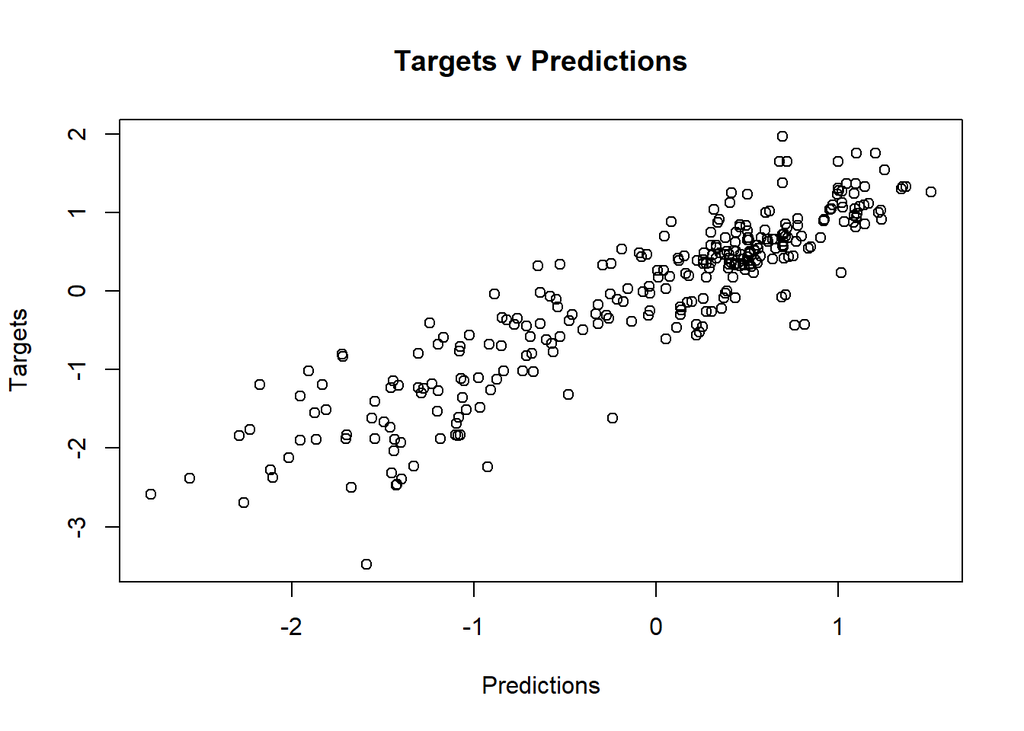

#### AIC, Validation ASE, Test ASE, and Test ASE Unstandardized

```
##   modelNum trainAIC    valASE   testASE testASEUnstandard
## 5        5 2703.706 0.1881469 0.1950666          17.58787
```